# Логистическая регрессия

07.04.2026

### 1. Статистика под капотом

Типы переменных

- числовые
- категориальные

Что нам известно:

- Доверительные интервалы (числовая переменная)
- Критерий Фишера (категориальная переменная)
- Простая линейная регрессия (числовая переменная на одну числовую переменную)
- Линейная регрессия с дамми-переменными (числовая переменная на любую (т. е. числовую или категориальную) переменную)
- H0 для линейной регрессии - значение коэффициента независимой переменной равно 0
- Доверительный интервал коэффициента независимой переменной не должен пересекать 0

Основные регрессии на сегодня:  
* Множественная линейная регрессия (числовая переменная на несколько числовых переменных)  
* Множественная линейная регрессия с дамми-переменными (числовая переменная на числовые или категориальные переменные)  
* Логистическая (логит) регрессия (бинарная зависимая переменная на любое количество переменных любого типа)

### 2.1 Как это работает

Логистическая и логит-регрессия [Cox 1958] – это регрессионная модель, которая предсказывает категориальную зависимую переменную, используя любое количество переменных любого типа. Бинарная логистическая регрессия предсказывает бинарную зависимую переменную (YES – NO, TRUE – FALSE, успех – провал).

Что нам нужно? Для линейной модели:

$$\underbrace{y_i}_{[-\infty,
+\infty]}=\underbrace{\beta_0+\beta_1\cdot x_1+\beta_2\cdot x_2 + \dots
+\beta_z\cdot x_z +\epsilon_i}_{[-\infty, +\infty]}$$

Но в нашем случае $y$ – это бинарная переменная.

- вероятность?

$$P(y) = \frac{\mbox{# successes}}{\mbox{#
failures} + \mbox{# successes}}; P(y) \in [0, 1]$$

- отношение шансов?

$$odds(y) = \frac{P(y)}{1-P(y)} =
\frac{\mbox{P(successes)}}{\mbox{P(failures)}} = \frac{\mbox{#
successes}}{\mbox{# failures}}; odds(y) \in [0, +\infty]$$

- натуральный логарифм отношения шансов

$$\log(odds(y)) \in [-\infty,
+\infty]$$

### 2.2 Вспоминаем свойства логарифмов

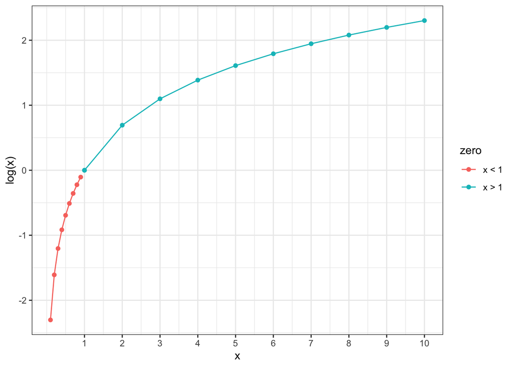

- если log(odds) больше 0, это означает, что у нас больше успехов, чем провалов;
- если log(odds) равно 0, это означает, что у нас одинаковое количество успехов и провалов;
- если log(odds) меньше 0, это означает, что у нас меньше успехов, чем провалов;

### 2.3 Вероятности и log(odds)

```
##     s  f P(s)   odds(s) log(odds(s))
## 1   0 10  0.0 0.0000000         -Inf
## 2   1  9  0.1 0.1111111   -2.1972246
## 3   2  8  0.2 0.2500000   -1.3862944
## 4   3  7  0.3 0.4285714   -0.8472979
## 5   4  6  0.4 0.6666667   -0.4054651
## 6   5  5  0.5 1.0000000    0.0000000
## 7   6  4  0.6 1.5000000    0.4054651
## 8   7  3  0.7 2.3333333    0.8472979
## 9   8  2  0.8 4.0000000    1.3862944
## 10  9  1  0.9 9.0000000    2.1972246
## 11 10  0  1.0       Inf          Inf
```

$$\log(odds(s)) =
\log\left(\frac{\#s}{\#f}\right)$$
$$P(s) =
\frac{\exp(\log(odds(s)))}{1+\exp(\log(odds(s)))}$$

Результаты логистической регрессии легко можно преобразовать в вероятности.

### 2.4 Сигмоидная функция

или связывающая функция логит-регрессии.

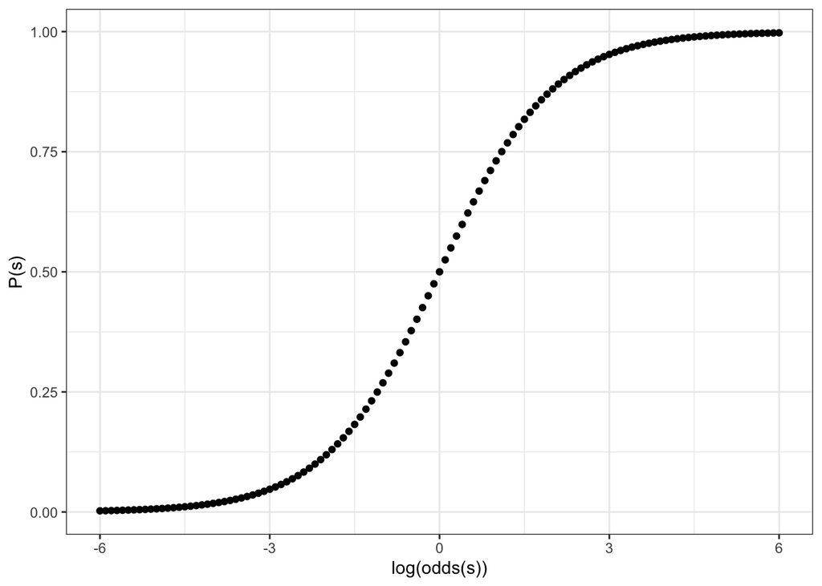

Формула для этой сигмоидной функции выглядит следующим образом:

$$y = \frac{1}{1+e^{-x}}$$

С помощью логистической регрессии мы сможем обратно преобразовать нашу сигмоидную функцию:

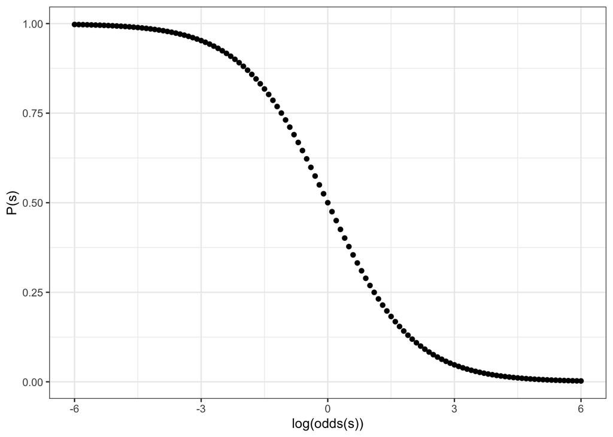

Формула для этой сигмоидной функции выглядит следующим образом:

$$y = \frac{1}{1+e^{-(-x)}} =
\frac{1}{1+e^{x}}$$

С помощью логистической регрессии мы сможем сместить центр нашей сигмоидной функции влево/вправо:

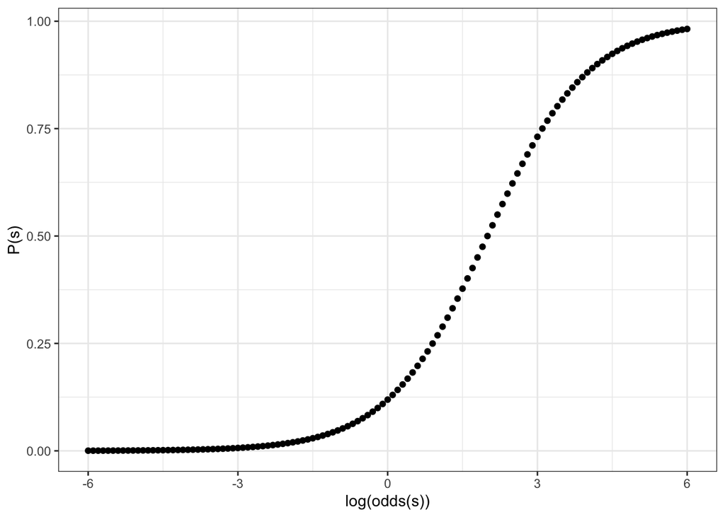

Формула для этой сигмоидной функции со смещением значения `x` на 2 выглядит как:

$$y = \frac{1}{1+e^{-(x-2)}}$$

С помощью логистической регрессии мы сможем также сжать/растянуть центральную часть нашей сигмоидной функции:

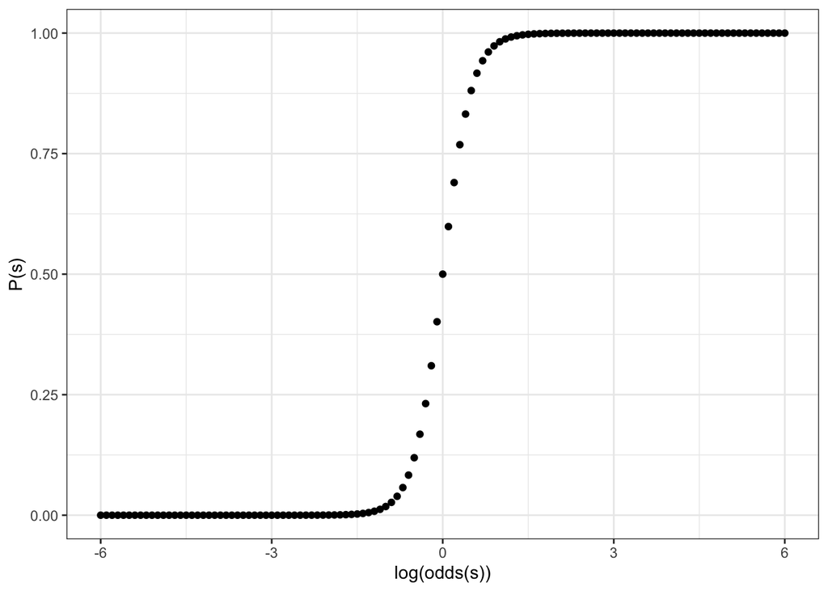

$$y = \frac{1}{1+e^{-4x}}$$

Таким образом, общая формула будет:

$$y = \frac{1}{1+e^{-k(x-z)}}$$

где

- в зависимости от значений $x$ сигмоидная функция может поворачиваться зеркально
- $k$ – это сжимающий/растягивающий коэффициент
- $z$ – это коэффициент, который позволяет сдвинуть центр сигмоиды влево или вправо

### 3. Логистическая регрессия в R

Посмотрим, верно ли, что языки с абруптивными звуками имеют в среднем больше согласных. Будем использовать данные из фонологической базы LAPSyD: http://goo.gl/0btfKa.

```r
ej_cons <- read.csv("http://goo.gl/0btfKa")  |>
  mutate(across(where(is.character), as_factor))
str(ej_cons)
```

```
## 'data.frame':    27 obs. of  3 variables:
##  $ name         : Factor w/ 27 levels "Turkish","Korean",..: 1 2 3 4 5 6 7 8 9 10 ...
##  $ n.cons.lapsyd: int  24 21 21 22 21 20 19 18 15 17 ...
##  $ ejectives    : Factor w/ 2 levels "no","yes": 1 1 1 1 1 1 1 1 1 1 ...
```

Визуализируем количество согласных в языках в языках с абруптивами и без:

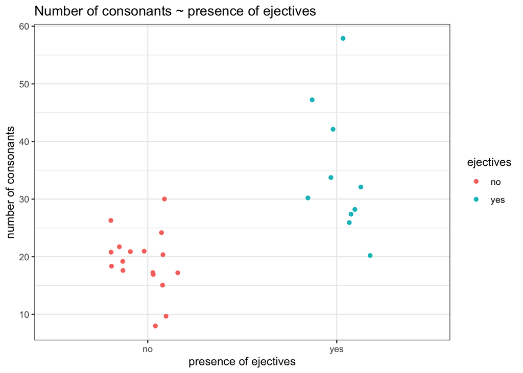

```r
ej_cons %>%
  ggplot(aes(ejectives, n.cons.lapsyd, color = ejectives))+
  geom_jitter(width = 0.2)+
  labs(title = "Number of consonants ~ presence of ejectives",
       x = "presence of ejectives",
       y = "number of consonants")+
  theme_bw()
```

- Модель без предикторов

Логистическая модель без переменных-предикторов строит свои оценки только на основании интерцепта `(y~1)`, то есть свойств распределения зависимой переменной (независимо от других переменных). В данном случае это вероятность получить значение `ejectives=yes` Проверьте, что зависимая переменная представлена как фактор.

```r
fit1 <- glm(ejectives~1, data = ej_cons, family = "binomial")
summary(fit1)
```

```
##
## Call:
## glm(formula = ejectives ~ 1, family = "binomial", data = ej_cons)
##
## Coefficients:
##             Estimate Std. Error z value Pr(>|z|)
## (Intercept)  -0.5306     0.3985  -1.331    0.183
##
## (Dispersion parameter for binomial family taken to be 1)
##
##     Null deviance: 35.594  on 26  degrees of freedom
## Residual deviance: 35.594  on 26  degrees of freedom
## AIC: 37.594
##
## Number of Fisher Scoring iterations: 4
```

Собственно, распределение ответов `yes` и `no` показательно:

```r
table(ej_cons$ejectives)
```

```
##
##  no yes
##  17  10
```

```r
log(10/17)
```

```
## [1] -0.5306283
```

```r
0.5306283 / (1 + exp(-0.5306283))
```

```
## [1] 0.3340993
```

- Модель с количественными предикторами

```r
fit2 <- glm(ejectives~n.cons.lapsyd, data = ej_cons, family = "binomial")
summary(fit2)
```

```
##
## Call:
## glm(formula = ejectives ~ n.cons.lapsyd, family = "binomial",
##     data = ej_cons)
##
## Coefficients:
##               Estimate Std. Error z value Pr(>|z|)
## (Intercept)    -9.9204     3.7699  -2.631   0.0085 **
## n.cons.lapsyd   0.3797     0.1495   2.540   0.0111 *
## ---
## Signif. codes:  0 '***' 0.001 '**' 0.01 '*' 0.05 '.' 0.1 ' ' 1
##
## (Dispersion parameter for binomial family taken to be 1)
##
##     Null deviance: 35.594  on 26  degrees of freedom
## Residual deviance: 16.202  on 25  degrees of freedom
## AIC: 20.202
##
## Number of Fisher Scoring iterations: 6
```

Модель сообщает, что `n.cons.lapsyd` является значимым предиктором. Коэффициент 0.3797 значимо отличается от 0 (p-value=0.0111 на основании распределения статистики z).

Распаковка модели:

$$\log(odds(ej)) = \beta_o + \beta_1
\times n.cons.lapsyd =
-9.9204 + 0.3797 \times n.cons.lapsyd$$

Визуализируем нашу модель:

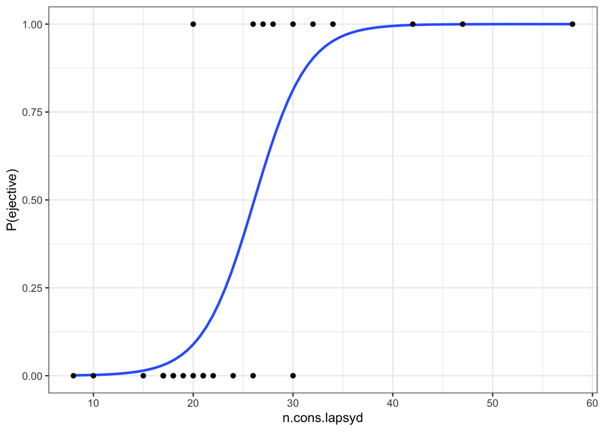

```r
ej_cons %>%
  mutate(`P(ejective)` = as.numeric(ejectives) - 1) %>%
  ggplot(aes(x = n.cons.lapsyd, y = `P(ejective)`))+
  geom_smooth(method = "glm", method.args = list(family = "binomial"), se = FALSE) +
  geom_point()+
  theme_bw()
```

### 4. predict(): Оценка предсказаний модели

```r
new.df <- data.frame(n.cons.lapsyd = c(30, 55, 34, 10))
predict(fit2, new.df) # odds
```

```
##         1         2         3         4
##  1.470850 10.963579  2.989686 -6.123334
```

```r
predict(fit2, new.df, type = "response") # probabilities
```

```
##           1           2           3           4
## 0.813186486 0.999982679 0.952106011 0.002186347
```

```r
predict(fit2, new.df, type = "response", se.fit = TRUE) # probabilities and confidense interval
```

```
## $fit
##           1           2           3           4
## 0.813186486 0.999982679 0.952106011 0.002186347
##
## $se.fit
##            1            2            3            4
## 1.512886e-01 7.882842e-05 6.869366e-02 5.038557e-03
##
## $residual.scale
## [1] 1
```

Построим график с доверительными интервалами.

```r
ej_cons_ci <- cbind.data.frame(ej_cons, predict(fit2, ej_cons, type = "response", se.fit = TRUE)[1:2])
ej_cons_ci
```

```
##          name n.cons.lapsyd ejectives         fit       se.fit
## 1     Turkish            24        no 0.308443627 1.376976e-01
## 2      Korean            21        no 0.124931874 9.358363e-02
## 3        Tiwi            21        no 0.124931874 9.358363e-02
## 4      Kpelle            22        no 0.172669632 1.090491e-01
## 5        Tulu            21        no 0.124931874 9.358363e-02
## 6  Mapudungun            20        no 0.088972775 7.806484e-02
## 7       Kiowa            19        no 0.062623081 6.341445e-02
## 8     Guarani            18        no 0.043702625 5.034610e-02
## 9    Japanese            15        no 0.014417525 2.278884e-02
## 10      Batak            17        no 0.030313786 3.921885e-02
## 11     Yoruba            18        no 0.043702625 5.034610e-02
## 12    Finnish            17        no 0.030313786 3.921885e-02
## 13  Kayardild            17        no 0.030313786 3.921885e-02
## 14   Hawaiian             8        no 0.001024268 2.658820e-03
## 15      Maori            10        no 0.002186347 5.038557e-03
## 16  Hungarian            26        no 0.488005505 1.637595e-01
## 17    Kannada            30        no 0.813186486 1.512886e-01
## 18   Georgean            28       yes 0.670717326 1.740778e-01
## 19     Ingush            34       yes 0.952106011 6.869366e-02
## 20     Abkhaz            58       yes 0.999994456 2.769836e-05
## 21    Amharic            32       yes 0.902934848 1.088031e-01
## 22    Sandawe            47       yes 0.999638868 1.216840e-03
## 23    Tlingit            42       yes 0.997593950 6.337117e-03
## 24     Lakota            30       yes 0.813186486 1.512886e-01
## 25    Yucatec            20       yes 0.088972775 7.806484e-02
## 26     Aymara            27       yes 0.582178309 1.725265e-01
## 27       Pomo            26       yes 0.488005505 1.637595e-01
```

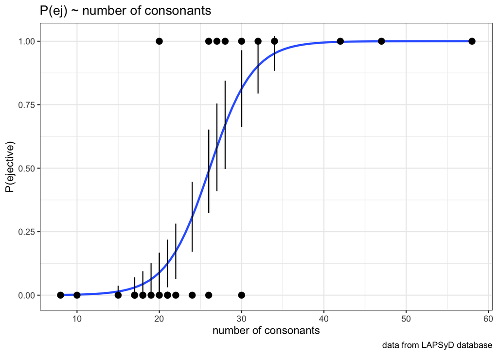

```r
ej_cons_ci %>%
  mutate(`P(ejective)` = as.numeric(ejectives) - 1) %>%
  ggplot(aes(x = n.cons.lapsyd, y = `P(ejective)`))+
  geom_smooth(method = "glm", method.args = list(family = "binomial"), se = FALSE)+
  geom_point() +
  geom_pointrange(aes(x = n.cons.lapsyd, ymin = fit - se.fit, ymax = fit + se.fit))+
  labs(title = "P(ej) ~ number of consonants",
       x = "number of consonants",
       caption = "data from LAPSyD database")+
  theme_bw()
```

### 5. Модель с несколькими предикторами

$$\underbrace{\log(odds(y))}_{[-\infty,
+\infty]}=\underbrace{\beta_0+\beta_1\cdot x_1+\beta_2\cdot x_2 + \dots
+\beta_z\cdot x_z +\epsilon}_{[-\infty, +\infty]}$$

Обратите внимание, что значимость предиктора может меняться в моделях с разным набором предикторов. Задача состоит в том, чтобы выбрать модель, в которой все предикторы статистически значимы (имеют коэффициент, значимо отличающийся от 0).

### 6. Выбор модели

**AIC** (Akaike Information Criterion) – показатель модели (goodness-of-fit measure), используемый для сравнения моделей с разным количеством предикторов. Он наказывает модель за слишком большое количество предикторов. Чем меньше AIC, тем лучше.  
Сравнивая модели, мы ориентируемся на **минимальную оптимальную модель** (minimal optimal model):  
* оптимальная, так как позволяет предсказать ответ наилучшим образом  
* минимальная оптимальная, так как использует минимально необходимое количество предикторов

Другие способы оценить логистическую модель:  
* accuracy  
* concordance index C (the area under the ROC-curve)  
* Nagelkerke pseudo-$R^{2}$

### 7. Взаимодействие переменных

Взаимодействие происходит, когда влияние одного предиктора на результат зависит от значения другого предиктора. Взаимодействие двух предикторов может быть положительным (сочетание их значений усиливает эффект) или отрицательным (сочетание их значений уменьшает эффект). Пример: одушевленность и семантический класс; одушевленность и выбор синтаксической конструкции; влияние переходности глаголов в разных языковых вариантах.

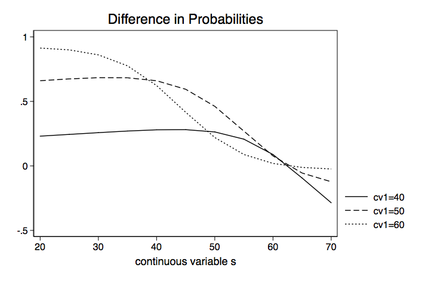

### 8. Заключение: Обобщенные линейные модели (GLM)

Обобщенная линейная модель (GLM) — это широкий класс моделей, включающий линейную регрессию, логистическую регрессию, логарифмическую линейную регрессию, регрессию Пуассона, дисперсионный анализ (ANOVA), ковариационный анализ (ANCOVA) и т. д. Для того чтобы конкретный метод назывался GLM, он должен иметь следующие три компонента:

- **Случайный компонент**: Он относится к зависимой переменной (y), которая должна удовлетворять определенным предположениям. Примеры: Линейная регрессия y (зависимая переменная) подчиняется нормальному распределению. Логистическая регрессия подчиняется биномиальному распределению.
- **Систематический компонент**: Это не что иное, как объясняющие переменные в модели. Систематические компоненты помогают объяснить случайный компонент.
- **Функция связи (Link Function)**: Это связь между систематическим и случайным компонентами, т. е. связь между левой и правой частями уравнения. Функция связи показывает, как ожидаемое значение зависимой переменной связано с объясняющей переменной. Функция связи линейной регрессии — E[y], а функция связи логистической регрессии — сигмоида (logit).

### Что запомнить из сегодняшнего занятия?

- Классификаторы: бинарный, многоклассовый (мультиномиальный)
- отношение шансов (odds)
- сигмоида
- значимость переменных (предикторов)
- взаимодействия